# Bayesian Linear Regression

Simon Thornewill von Essen

12/22/2019

In this R Markdown we will be doing some bayesian linear regression.

We will be doing a regression of the infant mortality rate in various countries.

```r
head(Leinhardt, 5)
```

```
##           income infant   region oil
## Australia   3426   26.7     Asia  no
## Austria     3350   23.7   Europe  no
## Belgium     3346   17.0   Europe  no
## Canada      4751   16.8 Americas  no
## Denmark     5029   13.5   Europe  no
```

```r
str(Leinhardt)
```

```
## 'data.frame':    105 obs. of  4 variables:
##  $ income: int  3426 3350 3346 4751 5029 3312 3403 5040 2009 2298 ...
##  $ infant: num  26.7 23.7 17 16.8 13.5 10.1 12.9 20.4 17.8 25.7 ...
##  $ region: Factor w/ 4 levels "Africa","Americas",..: 3 4 4 2 4 4 4 4 4 4 ...
##  $ oil   : Factor w/ 2 levels "no","yes": 1 1 1 1 1 1 1 1 1 1 ...
```

We can have a look at the scatterplot for this data using the pairs function, as before.

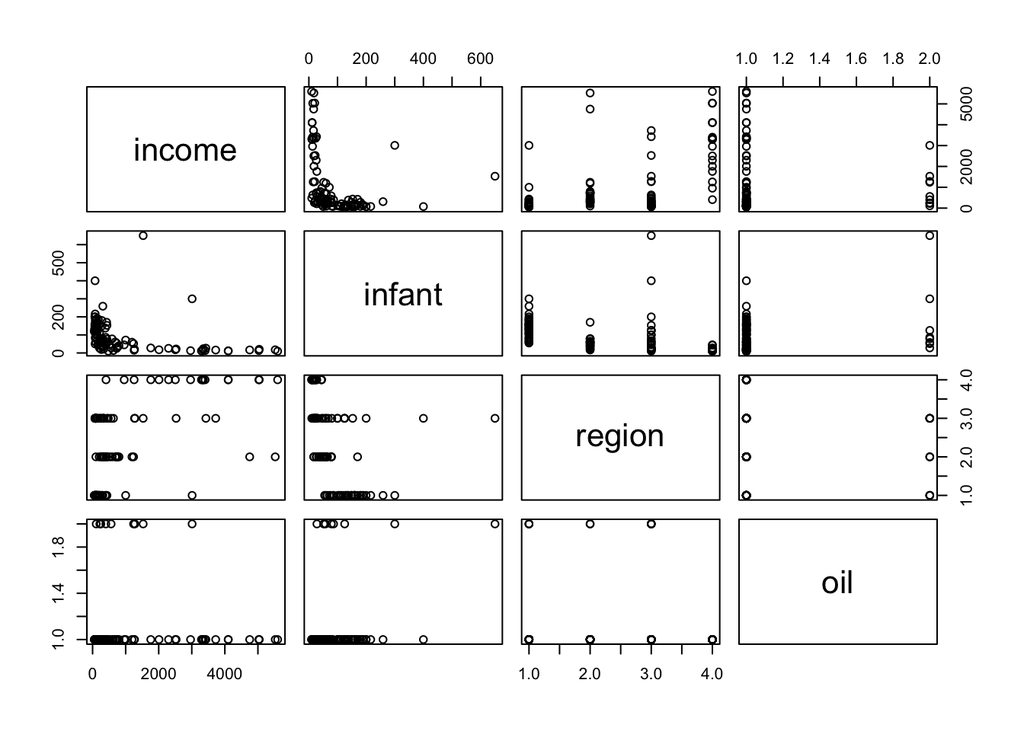

```r
pairs(Leinhardt)
```

If we were doing a regression on only infant mortality and income, we would imagine that the linear model might not be an appropriate choice. However, since both variables have considerable right skewness, we could consider taking the log transform of both.

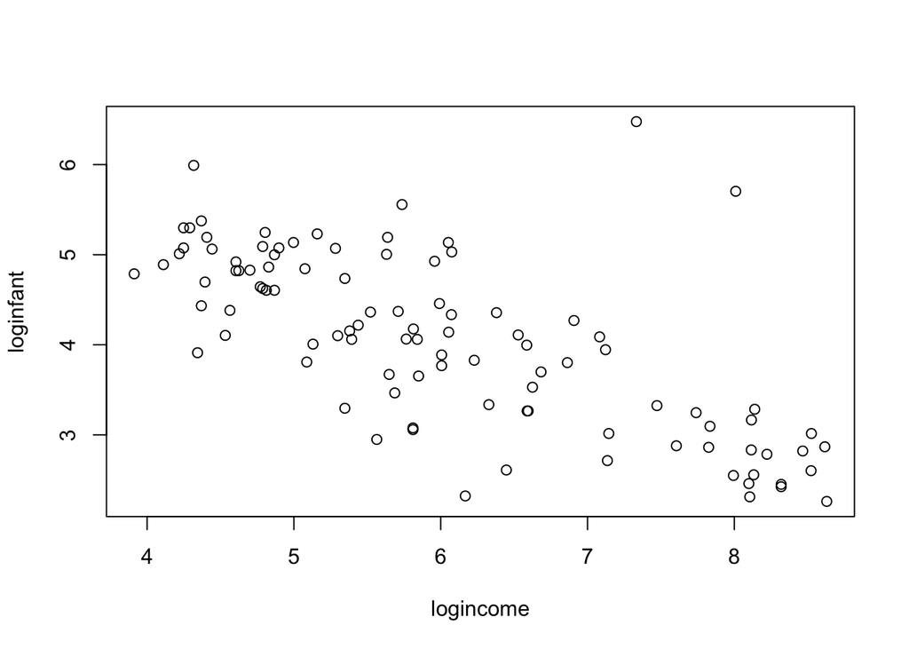

```r
Leinhardt$loginfant <- log(Leinhardt$infant)
Leinhardt$logincome <- log(Leinhardt$income)

plot(loginfant ~ logincome, data=Leinhardt)
```

We could easily imagine fitting a straight line through this.

## Modeling

The reference bayesian analysis with a flat prior can be done using the linear model function in R.

```r
lmod <- lm(loginfant ~ logincome, data=Leinhardt)

summary(lmod)
```

```
##
## Call:
## lm(formula = loginfant ~ logincome, data = Leinhardt)
##
## Residuals:
##      Min       1Q   Median       3Q      Max
## -1.66694 -0.42779 -0.02649  0.30441  3.08415
##
## Coefficients:
##             Estimate Std. Error t value Pr(>|t|)
## (Intercept)  7.14582    0.31654  22.575   <2e-16 ***
## logincome   -0.51179    0.05122  -9.992   <2e-16 ***
## ---
## Signif. codes:  0 '***' 0.001 '**' 0.01 '*' 0.05 '.' 0.1 ' ' 1
##
## Residual standard error: 0.6867 on 99 degrees of freedom
##   (4 observations deleted due to missingness)
## Multiple R-squared:  0.5021, Adjusted R-squared:  0.4971
## F-statistic: 99.84 on 1 and 99 DF,  p-value: < 2.2e-16
```

We notice that some observations were omitted due to missing values. We will exclude them explicitly.

```r
dat <- na.omit(Leinhardt)
```

### Using JAGS

Now that we have had a look at a bayesian linear regression using uninformative/flat priors, let’s take a look at how we might build something in JAGS

```r
mod1_string = "model{
  for(i in 1:n){
    y[i] ~ dnorm(mu[i], prec)
    mu[i] <- b[1] + b[2]*log_income[i]
  }

  for(j in 1:2){
     b[j] ~ dnorm(0.0, 1/1.0e6)
  }

  prec ~ dgamma(5.0/2, 5.0*10/2)
  sig2 <- 1/prec
  sig <- sqrt(sig2)
}"
```

Now we need to define a couple of other things for our model.

```r
set.seed(72)

data1_jags <- list(y=dat$loginfant,
                   n=nrow(dat),
                   log_income=dat$logincome)

params1 <- c("b", "sig")

inits1 <- function(){
  inits <- list("b"=rnorm(2, 0.0, 100.0),
                "prec"=rgamma(1, 1.0, 1.0))
}
```

Create the model

```r
mod1 <- jags.model(textConnection(mod1_string),
                   data=data1_jags,
                   inits=inits1,
                   n.chains=3)
update(mod1, 1000)

mod1_sim <- coda.samples(model=mod1, variable.names = params1, 5000)
```

Note that we have three chains, it would be useful to combine them into one chain.

```r
mod1_csim <- do.call(rbind, mod1_sim)
```

## Post Processing

Now that we have completed sampling from our posterior distribution, we should check for convergence.

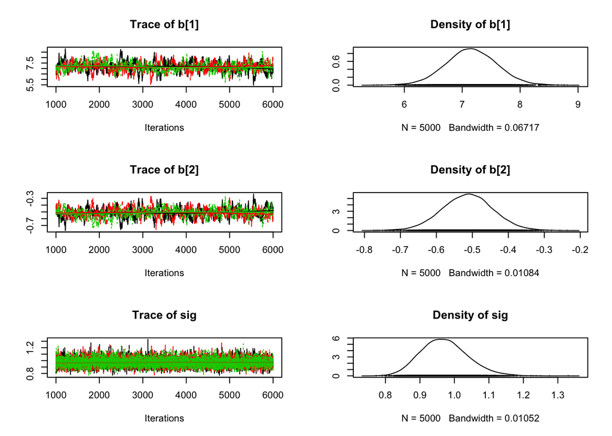

```r
plot(mod1_sim)
```

```r
gelman.diag(mod1_sim)
```

```
## Potential scale reduction factors:
##
##      Point est. Upper C.I.
## b[1]       1.01       1.03
## b[2]       1.01       1.03
## sig        1.00       1.00
##
## Multivariate psrf
##
## 1.01
```

The gelman diagnostics are pretty close to 1, so we can conclude that we have converged.

```r
autocorr.diag(mod1_sim)
```

```
##             b[1]      b[2]           sig
## Lag 0  1.0000000 1.0000000  1.0000000000
## Lag 1  0.9516777 0.9518443  0.0075650345
## Lag 5  0.7924835 0.7922677 -0.0060998015
## Lag 10 0.6291339 0.6308341  0.0002558377
## Lag 50 0.1249628 0.1238804 -0.0031262286
```

We can see for the first couple of iterations the autocorrelation was pretty high, so we also want to check our effective sample size.

```r
effectiveSize(mod1_sim)
```

```
##       b[1]       b[2]        sig
##   362.6818   349.4032 13400.9637
```

It seems like our sigma value mixed quite well, not so much so for b1 and b2. Note that our sample size is equal to 3*5000=15000, so the effective sample size of the bs leaves something quite to be desired.

```r
summary(mod1_sim)
```

```
##
## Iterations = 1001:6000
## Thinning interval = 1
## Number of chains = 3
## Sample size per chain = 5000
##
## 1. Empirical mean and standard deviation for each variable,
##    plus standard error of the mean:
##
##         Mean      SD  Naive SE Time-series SE
## b[1]  7.1560 0.43940 0.0035877      0.0232184
## b[2] -0.5134 0.07109 0.0005805      0.0038531
## sig   0.9711 0.06788 0.0005543      0.0005953
##
## 2. Quantiles for each variable:
##
##         2.5%     25%     50%     75%   97.5%
## b[1]  6.2867  6.8677  7.1535  7.4487  8.0233
## b[2] -0.6545 -0.5605 -0.5127 -0.4667 -0.3727
## sig   0.8501  0.9233  0.9677  1.0143  1.1148
```

We can compare these results to what we got from `lmod`, it should be noted that out results are quite similar because our priors were still rather uninformative.

Let’s also take a look as the residuals…

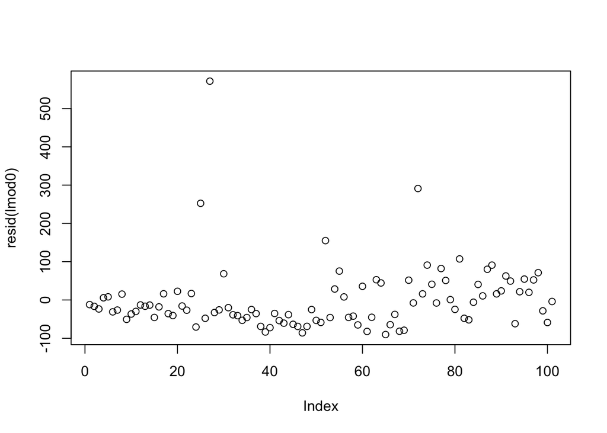

```r
lmod0 <- lm(infant ~ income, data=Leinhardt)

plot(resid(lmod0))
```

We dont want to see any patterns in this data, for the index of the model we plotted the residuals for the model, if the data are random when we should see the residuals hovering around one point.

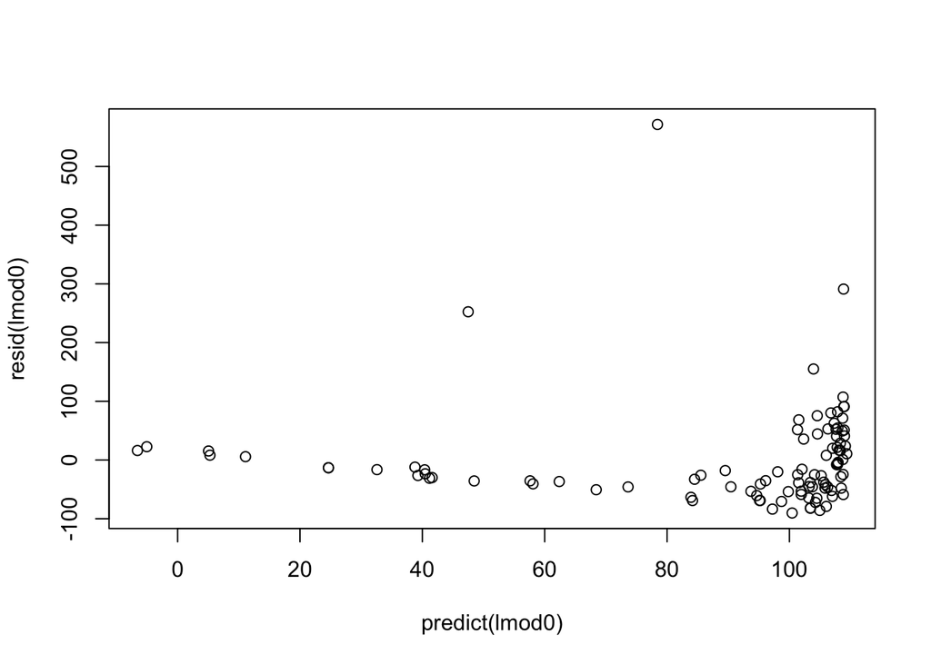

```r
plot(predict(lmod0), resid(lmod0))
```

Here, we can see that as the prediction gets bigger, we see a downward trend in the residuals until we reach a prediction of roughly 100, where the residuals skyrocket. This should lead us to believe that residuals past 100 violate the assumptions of a linear model.

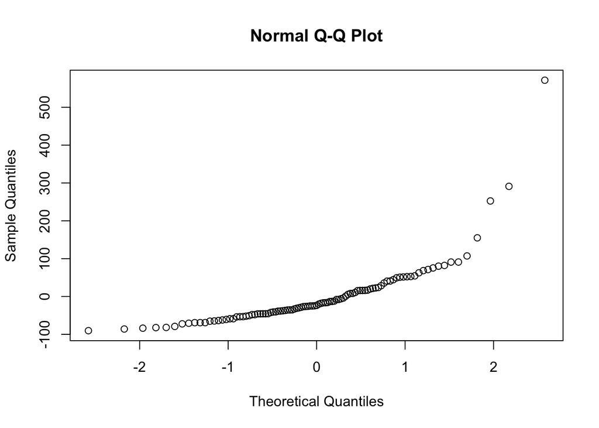

```r
qqnorm(resid(lmod0))
```

We can also plot the sample quantiles against the theoretical quantiles. If this distribution is normally distributed then we should see a straight line here, but unfortunately the quantiles past roughly 1.5 start to violate this assumption.

Now that we know what are residuals shouldn’t look like, we should have a look at the results of our bayesian analysis.

```r
X <- cbind(rep(1.0, data1_jags$n),
           data1_jags$log_income)

pm_params1 <- colMeans(mod1_csim)

yhat1 <- drop(X %*% pm_params1[1:2])
resid1 <- data1_jags$y - yhat1
```

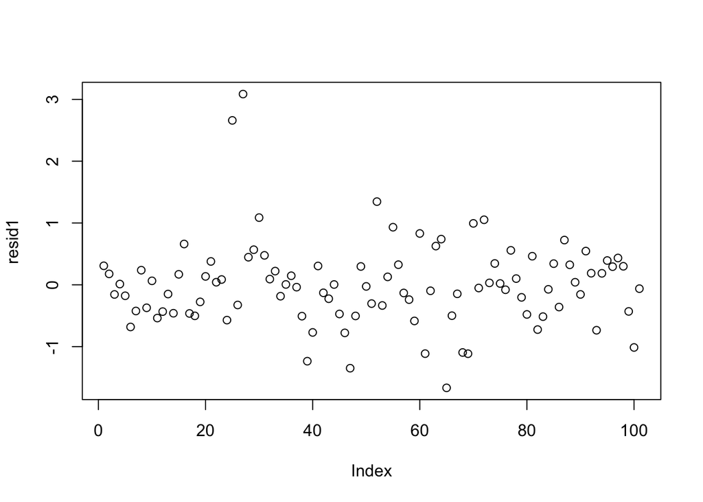

```r
plot(resid1)
```

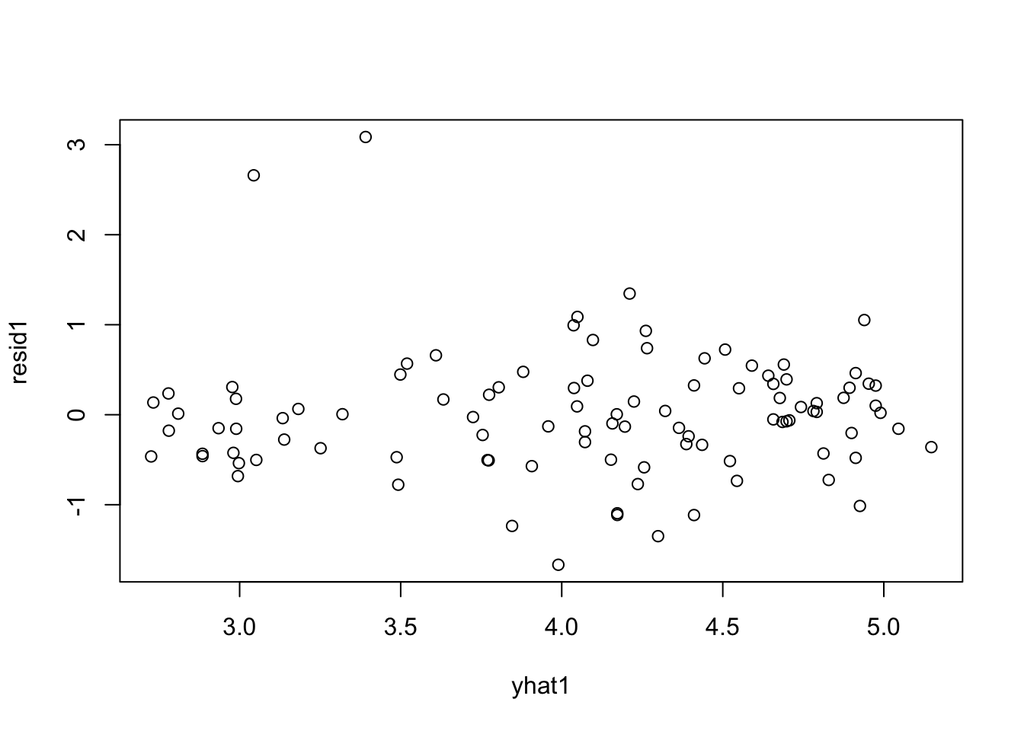

```r
plot(yhat1, resid1)
```

We can build one concern with this plot, namely, that the variance of the residuals slowly increases as the predicted variable increases, and we can see two clear outliers as well.

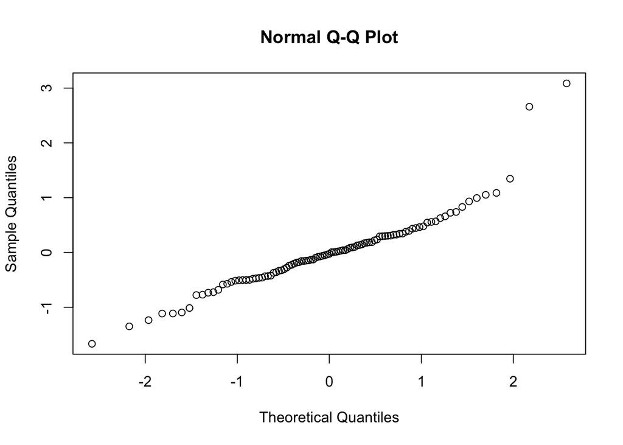

```r
qqnorm(resid1)
```

Once again, the data looks alright if it werent for the outliers. Let’s have a look at what these are.

```r
head(rownames(dat)[order(resid1, decreasing = TRUE )])
```

```
## [1] "Saudi.Arabia" "Libya"        "Zambia"       "Brazil"       "Afganistan"
## [6] "Turkey"
```

We would now double check the data somehow. If it were found that these datapoints were erronious we could correct them. Otherwise, we might be able to find reasons why we can drop them from our dataset because they do not fit what we are trying to model.

## Alternative Models

But, what if you decide that you cannot drop these two points. What do you do then?

The first thing you can do is look for explanatory variables, these extra features may help the model to discern between outliers a little better.

```r
set.seed(75)

mod2_string = "model{
  for(i in 1:n){
    y[i] ~ dnorm(mu[i], prec)
    mu[i] <- b[1] + b[2]*log_income[i] + b[3]*is_oil[i]
  }

  for(j in 1:3){
     b[j] ~ dnorm(0.0, 1/1.0e6)
  }

  prec ~ dgamma(5.0/2, 5.0*10/2)
  sig2 <- 1/prec
  sig <- sqrt(sig2)
}"

data2_jags <- list(y=dat$loginfant,
                   n=nrow(dat),
                   log_income=dat$logincome,
                   is_oil=as.numeric(dat$oil=="yes"))

params1 <- c("b", "sig")

inits2 <- function(){
  inits <- list("b"=rnorm(3, 0.0, 100.0),
                "prec"=rgamma(1, 1.0, 1.0))
}

mod2 <- jags.model(textConnection(mod2_string),
                   data=data2_jags,
                   inits=inits2,
                   n.chains=3)
```

Update the model…

```r
update(mod2, 1000)

mod2_sim <- coda.samples(model=mod2, variable.names = params1, 5000)

mod2_csim <- as.mcmc(do.call(rbind, mod2_sim))
```

Normally, you should always check if the trace has converged. However, we are skipping this here in the interest of time. The teacher for this course assures me that it has indeed converged.

```r
summary(mod2_sim)
```

```
##
## Iterations = 1001:6000
## Thinning interval = 1
## Number of chains = 3
## Sample size per chain = 5000
##
## 1. Empirical mean and standard deviation for each variable,
##    plus standard error of the mean:
##
##         Mean      SD  Naive SE Time-series SE
## b[1]  7.1325 0.43618 0.0035614      0.0228428
## b[2] -0.5200 0.07058 0.0005763      0.0036861
## b[3]  0.7917 0.35469 0.0028960      0.0031293
## sig   0.9519 0.06731 0.0005496      0.0005788
##
## 2. Quantiles for each variable:
##
##          2.5%     25%     50%     75%   97.5%
## b[1]  6.27440  6.8391  7.1360  7.4276  7.9921
## b[2] -0.65807 -0.5678 -0.5211 -0.4725 -0.3808
## b[3]  0.09674  0.5536  0.7913  1.0317  1.4910
## sig   0.83124  0.9046  0.9488  0.9943  1.0961
```

There seems to be a positive correlation between infant mortality and oil exportation in a country. Make sure to note that this does not mean there is a causal relationship, just that they have been observed to happen together.

```r
X2 <- cbind(rep(1, data2_jags$n), data2_jags$log_income, data2_jags$is_oil)

pm_params2 <- colMeans(mod2_csim)

y_hat2 <- X2 %*% pm_params2[1:3]
resid2 <- data2_jags$y - y_hat2
```

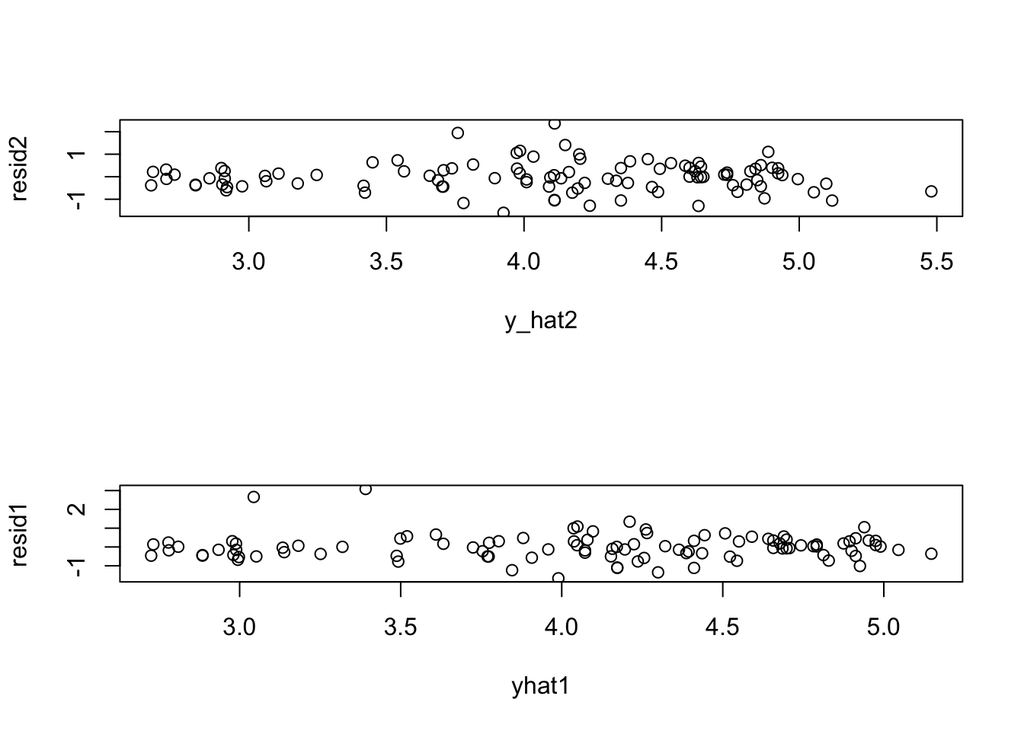

```r
par(mfrow=c(2, 1))
plot(y_hat2, resid2)
plot(yhat1, resid1)
```

We can see that the two outliers are now closer to the bulk of the data. They are still pretty extreme outliers when compared to the standard deviation of the data, but it’s a start.

### Condering alternate likelihoods

We can still note that the likelihood is a normal distribution, which is not as good at handling outliers as a t distribution. We can consider modeling with that instead.

## Comparing models

One final thing to discuss in this markdown is how we can compare models. On example is through `deviance info. criterion` or DIC.

```r
dic.samples(mod1, n.iter = 1e3)
```

```
## Mean deviance:  231.1
## penalty 2.863
## Penalized deviance: 233.9
```

```r
dic.samples(mod2, n.iter = 1e3)
```

```
## Mean deviance:  225.4
## penalty 3.978
## Penalized deviance: 229.4
```

We can interpret the deviance as a kind of “loss” of the model, we add a pentalty for adding complexity to the model. This means that although we made the model a little more complex but adding this complexity was worth it overall.